# Practical Machinelearning

Carl-Johan Rosenberg

21/03/2015

## Data processing

The first step in the analysis is to download the data and load it into R.

```r
#Link from where to receive the data
url_training<-"https://d396qusza40orc.cloudfront.net/predmachlearn/pml-training.csv"
url_testing<-"https://d396qusza40orc.cloudfront.net/predmachlearn/pml-testing.csv"

message("Downloads the files")
#Downloads the data into a file ./data/data.zip, wget to allows for the https
download.file(url_training,destfile='./data/training.csv',method = "wget",mode = 'wb')
download.file(url_testing,destfile='./data/testing.csv',method = "wget",mode = 'wb')

message("Unzips and loads the data")
#Reads the unzipped the data into a data
training <- read.csv('./data/training.csv',sep = ',',stringsAsFactors = FALSE, header = TRUE)
testing<- read.csv('./data/testing.csv',sep = ',',stringsAsFactors = FALSE, header = TRUE)
```

After downloading the data the next step is to view it and it consists of 19622 observations and 160 columns. In the research papers http://groupware.les.inf.puc-rio.br/har the approach taken is to in addition to the raw data use a time series based approach based on rolling windows. As the primary objective is to predict the 20 test samples, and it is unknown as to which window they would belong only the raw data features will be used.

```r
# Excluding na values
training <- training[, !apply(is.na(training), 2, any)]
testing <- testing[, !apply(is.na(testing), 2, any)]
# Excluding empty values
training <- training[, !apply(training, 2, function(x) any(x == ""))]
testing <- testing[, !apply(testing, 2, function(x) any(x == ""))]

training <- training[, -c(1:7)]
testing <- testing[, -c(1:7)]
```

## Model selection

There are several methods of fitting the data. Such as simple methods such as lm, glm, lda to ensemble methods like random forest, bagging and boosting. The advantage of using methods like lm, glm, lda is that they are simple to use and are easy to interpret. With the ensemble methods the random forest, bagging and boosting, the interpretatibility is lost while in general the predictive ability increases.

Both the random forest and boosting methodologies have been tested and it is important to tune the parameters to get the right compromise between performance and accuracy.

In terms of learning for the current case as the data set is relatively large it is important when specifying model and determining the parameters to have a quick iteration time, which can be achieved by exploring the data using sampling to select a small subset like a few percent of the data to explore parameters to determine the tuning.

Using the caret training method it has also been shown that using the parallel computing to increase the processing speed which can be significant. In addition to the parallel computing also using the gc() garbage collecting function has proved to be useful.

```r
registerDoParallel(clust <- makeForkCluster(detectCores()))
#Takes about half an hour to run the simulation
InTrain<-createDataPartition(y=training$classe,p=0.05,list=FALSE)
training1<-training[InTrain,]

gbmGrid <-  expand.grid(interaction.depth = c(1,3,5,9),
                        n.trees = c(50,100,200,300,500,1000),
                        shrinkage = 0.1)

fitControl <- trainControl(method = "repeatedcv",
                           number = 3,
                           repeats = 3,
                           ## Estimate class probabilities
                           classProbs = TRUE)

gbmFit <- train(as.factor(classe)~.,data=training1,
                 method = "gbm",
                 trControl = fitControl,
                 verbose = FALSE,
                 tuneGrid = gbmGrid,
                 ## Specify which metric to optimize
                 metric = "ROC")
stopCluster(clust)
```

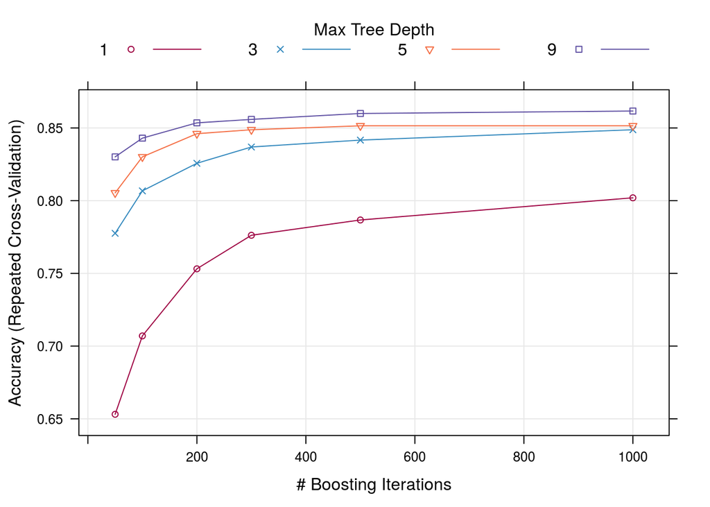

```r
trellis.par.set(caretTheme())
plot(gbmFit)
```

## Final Model

```r
registerDoParallel(clust <- makeForkCluster(detectCores()))
#Takes about half an hour to run the simulation
InTrain<-createDataPartition(y=training$classe,p=1,list=FALSE)
training1<-training[InTrain,]

gbmGrid <-  expand.grid(interaction.depth = c(5),
                        n.trees = c(300),
                        shrinkage = 0.1)

fitControl <- trainControl(method = "repeatedcv",
                           number = 3,
                           repeats = 3,
                           ## Estimate class probabilities
                           classProbs = TRUE)

gbmFit <- train(as.factor(classe)~.,data=training1,
                 method = "gbm",
                 trControl = fitControl,
                 verbose = FALSE,
                 tuneGrid = gbmGrid,
                 ## Specify which metric to optimize
                 metric = "ROC")

trellis.par.set(caretTheme())
plot(gbmFit)
stopCluster(clust)
print(gbmFit)
```

[output not shown]